# Final Project: United States UFO Sightings

## Stat 321: Applied Data Analysis

### Fall 2016

### Dr. Jimin Lee

I chose the UFO sighting data set from Kaggle, I don't believe in any UFO conspiracies or anything, nor did I really expect to find much After looking at the map of sightings, it was already pretty evident that, after normalizing for population density, There would be nothing really significant to find. Making this map took forever, mainly because my data table had an extra space at the end of 'longitude ', which I did not notice when I first tried to extract the coordinates of the sightings:

```python
from IPython.display import display, HTML
import numpy as np
from pandas import read_table,DataFrame                 #import data frame reder
import matplotlib.pyplot as plt               #import plot library
from mpl_toolkits.basemap import Basemap      #import map
from scipy.stats import *                     #import everything from stats library
from numpy.random import permutation          #import permutation from numerical library
from itertools import combinations            #import
```

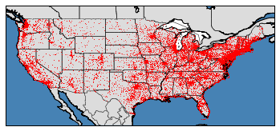

```python
data=read_table('/home/harris/Documents/R-Data/scrubbed.csv',sep=',',header=0)#read in data
usdat=data[data['country']=='us']             # extract us data
longs=usdat.loc[:,'longitude '].astype(float)          # get longitudes
lats=usdat.loc[:,'latitude'].astype(float)            # get latitudes
usmap = Basemap(projection='gall',            # gall stereographic projection
              llcrnrlon = -127,               # lower-left corner longitude
              llcrnrlat = 23,                 # lower-left corner latitude
              urcrnrlon = -65,                # upper-right corner longitude
              urcrnrlat = 52,                 # upper-right corner latitude
              resolution = 'f',               #full resolution
              area_thresh = 10000.0           # threshold for filling lakes and small islands
              )
x,y=usmap(longs.as_matrix(),lats.as_matrix()) # project coordinates to basemap (gall SP again)
usmap.drawcoastlines()
usmap.drawcountries()
usmap.drawstates()
usmap.fillcontinents(color = 'gainsboro')
usmap.drawmapboundary(fill_color='steelblue')
usmap.plot(x,y,'.',color='red',markersize=.56) # add points
```

```python
plt.show()
```

```python
print(usdat['state'].unique().shape[0]) #prints the number of states .shape returns (52,) so i ask for just the 52
usdat['state'].unique()                 #output will be the list of states
a=usdat['state'].unique().shape[0]
```

```
52
```

This data shows $52$ states including Washington D.C. and Puerto Rico. I have devided them into the following regions below:

$$\begin{array}{c} Northeast \\ Southeast \\ Midwest \\ Southwest \\ Northwest \end{array}$$

I put Hawaii in the Southwest group and Alaska in the Northwest group. I excluded the territory of Peurto Rico entirely

```python
neast=["ct","dc","de","ma","md","me","nh","nj","ny","pa","ri","vt"]
seast=["al","fl","ga","ky","la","ms","nc","sc","tn","va","wv"]
mwest=["ak","ia","il","in","ks","mi","mn","mo","nd","ne","oh","ok","sd","wi"]
swest=["az","ca","co","hi","nm","nv","tx","ut"]
nwest=["ak","id","mt","or","wa","wy"]
regions=[neast,seast,mwest,swest,nwest]
```

Now it's time to start testing, I will do a 1-way ANOVA of the regions with the observations being the sightings from each state. Because states with higher populations are likely to experience more sightings as well as more reports per sighting, I will normalize each state's number of sightings based on the state's population as a proportion of the US populaiton like this: $$sightings_{norm}(state)=\frac{sightings(state)}{.000001\cdot statePop}$$ To make this easier, I got a CSV from the US Census Bureau. I skipped the first row because it had data I did not need, and the last row because it was for Puerto Rico I made the second row the header of the data frame (indexing starts at 0 in Python). Because the Census data used the full state names, I created a CSV with the abbreviations sorted in the same order as the alphabatized states and will replace the old one:

```python
census=read_table('/home/harris/Documents/R-Data/census.csv',sep=',',skiprows=[0,54],header=1)
abrs=read_table('/home/harris/Documents/R-Data/abrs.csv',sep=',',header=-1)#must specify -1 for no header
census['United States.2']=abrs
```

```python
list(census.columns.values)
```

```
['0100000US',
 'Unnamed: 1',
 'United States',
 '0100000US.1',
 'Unnamed: 4',
 'United States.1',
 'United States.2',
 '281421906',
 '115904641',
 '3794083.06',
 '256644.62',
 '3537438.44',
 '79.6',
 '32.8']
```

Not sure why they chose to label the $Pop/mi^2$ column '79.6', seems like maybe my CSV was poorly formatted, I'll just fix it...

```python
densities=census['79.6']
pops=census['281421906']
areas=census['3537438.44']
```

The total data I got for the US included Peurto Rico, So, I recalculated it for my new data:

```python
USpop=sum(pops)
USarea=sum(areas)
USd=USpop/USarea
USd
```

```
79.555280119588446
```

```python
observedpdnorm=[sum(usdat['state']==abrs[0][i])/(densities[i]) for i in range(len(abrs))]
observedpnorm=[sum(usdat['state']==abrs[0][i])/(.000001*pops[i]) for i in range(len(abrs))]
```

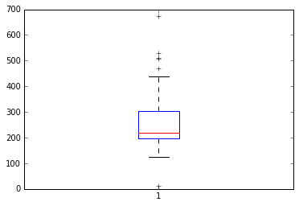

```python
plt.boxplot(observedpnorm)
plt.show()
```

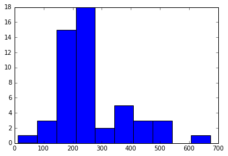

```python
plt.hist(observedpnorm)
plt.show()
```

```python
neobs=[observedpnorm[abrs[0][abrs[0]==state].index.values[0]]for state in neast]
seobs=[observedpnorm[abrs[0][abrs[0]==state].index.values[0]]for state in seast]
mwobs=[observedpnorm[abrs[0][abrs[0]==state].index.values[0]]for state in mwest]
swobs=[observedpnorm[abrs[0][abrs[0]==state].index.values[0]]for state in swest]
nwobs=[observedpnorm[abrs[0][abrs[0]==state].index.values[0]]for state in nwest]
```

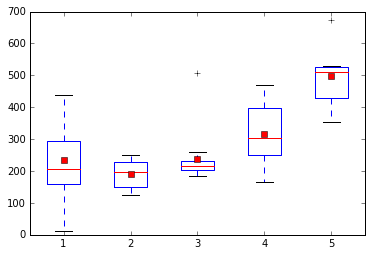

```python
obs=[neobs,seobs,mwobs,swobs,nwobs]
plt.boxplot(obs,showmeans=True)
plt.show()
```

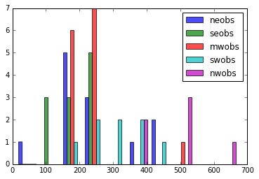

```python
names=['neobs','seobs','mwobs','swobs','nwobs']
plt.hist(obs,alpha=0.7,label=names)
plt.legend(loc='upper right')
plt.show()
```

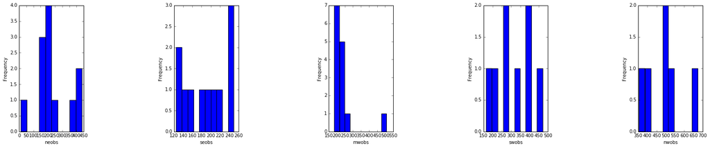

```python
fig = plt.figure(figsize=(30,5))

for i in range(len(obs)):
    ax = fig.add_subplot(1,2*len(obs),2*i+1)
    ax.hist(obs[i])
    ax.set_xlabel(names[i])
    ax.set_ylabel('Frequency')

plt.show()
```

Now I will do a one way F-Test, not expecting a very accutare result from this given the data:

```python
observedF=f_oneway(neobs,seobs,mwobs,swobs,neobs)
obsF=observedF.statistic
obsP=observedF.pvalue
obsP
```

```
0.15022553870255848
```

Got a p-value of $0.1502$ which means that I fail to reject the null that the distribution of sightings differs by region, but this data is not normally distributed, so I will now do a permutation F-Test by randomly permuting the observedpnorm values in each region:

```python
fStat=[]
for i in range(1000):
    obsSHUFF=permutation(observedpnorm)
    fStat.append(
               f_oneway(
                      obsSHUFF[0:11],
                      obsSHUFF[12:22],
                      obsSHUFF[23:36],
                      obsSHUFF[37:44],
                      obsSHUFF[45:50]
                      ).statistic
               )
```

```python
df=DataFrame({'P score Permutation f-test':[], str(sum(fStat>=obsF)/1000.0):[]})
display(HTML(df.to_html(index=False)))
```

| 0.148 | P score Permutation f-test |
| --- | --- |

Looks like my permutation F-Test reinforces the decision to fail to reject.

Now I will perform a similar Bonferroni corrected permutation sampling test on the pairwise K.S. tests for each pair of groups you can see my correction :

```python
pairs=[item for item in combinations(obs,2)]
```

```python
pairwise=[ks_2samp(pairs[i][0],pairs[i][1]).pvalue*len(pairs) for i in range(len(pairs))]
```

```python
pairnames=[item for item in combinations(names,2)]
df1=DataFrame({'Pair':pairnames,'P value':pairwise})
display(HTML(df1.to_html(index=False)))
```

| P value | Pair |
| --- | --- |
| 4.594817 | (neobs, seobs) |
| 1.359443 | (neobs, mwobs) |
| 1.231344 | (neobs, swobs) |
| 0.097664 | (neobs, nwobs) |
| 0.859544 | (seobs, mwobs) |
| 0.046129 | (seobs, swobs) |
| 0.001996 | (seobs, nwobs) |
| 0.088913 | (mwobs, swobs) |
| 0.003979 | (mwobs, nwobs) |
| 0.318623 | (swobs, nwobs) |

Looks like this test shows a significant difference between the ECDF for: southeast and southwest, southeast and northwest, midwest and northwest.

```python
permutedpairs=[]
for i in range(1000):
    obsSHUFF=permutation(observedpnorm)
    ne=obsSHUFF[0:11]
    se=obsSHUFF[12:22]
    mw=obsSHUFF[23:36]
    sw=obsSHUFF[37:44]
    nw=obsSHUFF[45:50]
    shuffs=[ne,se,mw,sw,nw]
    shuffPairs=[pair for pair in combinations(shuffs,2)]
    permutedpairs.append(
        [ks_2samp(shuffPairs[i][0],shuffPairs[i][1]).pvalue*len(shuffPairs) for i in range(len(shuffPairs))]
    )
```

```python
permutedpairs=np.asarray(permutedpairs)
p=[]
for i in range(len(shuffPairs)):
    p.append(sum(permutedpairs[:,i]<=pairwise[i])/1000.0)
```

```python
df2=DataFrame({'P Value':p,'Pair':pairnames})
display(HTML(df2.to_html(index=False)))
```

| P Value | Pair |
| --- | --- |
| 0.374 | (neobs, seobs) |
| 0.134 | (neobs, mwobs) |
| 0.124 | (neobs, swobs) |
| 0.008 | (neobs, nwobs) |
| 0.081 | (seobs, mwobs) |
| 0.004 | (seobs, swobs) |
| 0.000 | (seobs, nwobs) |
| 0.005 | (mwobs, swobs) |
| 0.001 | (mwobs, nwobs) |
| 0.035 | (swobs, nwobs) |

So, after running a one way $\textbf{ANOVA}$ and permutation F-Test and failing to find any significant differences in the population-normalized regional distributions, I decided to do pairwise K.S. tests on all the pairwise combinations, finding 3 groups that seemed to be different, I did a permutation pairwise K.S. test and found even more difference. Furthermore, a look at the boxplots and histograms gives a picture of a lot of overlap, with the potential for some of the groups to be distinct. I was going to run some of these tests as well as just tests on generating long lists of combinations in R as well, but This data was quite messy and incomplete for the research I was doing, so I spent a lot of time cleaning and formatting it, as well as some time learning how to use Python's MatPlotLib library to make my graphs. I think that since the Northwest showed up the most in my pairwise tests ans pairwise permutation tests, that it might be slightly more distinct fromt he other regions in sightings. Looking at the boxplots and histograms reinforces this hypothesis and lets me know the direction of the relationship. The Northwest seemed to experience more sightings per capita than any other region. I believe that, due to the existence of some extreme outliers, and the fact that I did not have time to come up with a particularly effective method of normalization (perhaps utilizing population density), this study could be improved upon with some further scrubbing of the data, though there are perhaps variables that are yet unnaccounted for, such as education, income, mental illness, or drug use. Attached are the CSV from Kaggle, a CSV of called census of population data, and a higher resolution image of the histograms. Have a Great break!